# Understanding Tucker Carlson’s Audience

Beliefs, Attitudes, and the Effects of an AI-Delivered Factual Intervention — Pilot Report

Published

February 18, 2026

**WarningPilot Data — Treat All Results as Preliminary**

This report is based on **17 completed responses** (of 42 total) collected on February 17, 2026. Statistical results have very low power at this sample size and should be replicated at full scale before drawing conclusions.

# 1 Study Overview

This study examines the beliefs, attitudes, and media consumption patterns of self-identified Tucker Carlson viewers. Participants completed a survey that included:

1. **Pre-treatment measures** — demographics, media engagement, conspiracy beliefs, foreign policy attitudes, and feelings toward Israel (Questions 1–12).
2. **An AI-delivered conversation** — participants engaged in a structured dialogue with an AI that provided factual context on Israel-related topics (the experimental manipulation, assigned via block randomization).
3. **Post-treatment measures** — the same attitude batteries administered again to detect opinion change (Questions 18–22), plus open-ended reflections on whether the conversation changed their views.

**Primary outcomes of interest:**

| Domain | Pre | Post |
| --- | --- | --- |
| Carlson credibility | Q8 | Q18 |
| Foreign policy views | Q9 | Q19 |
| Feelings toward Israel/Jewish people | Q10 | Q20 |
| Carlson’s Israel commentary | Q11 | Q21 |
| Israel policy positions | Q12 | Q22 |

# 2 Sample Characteristics

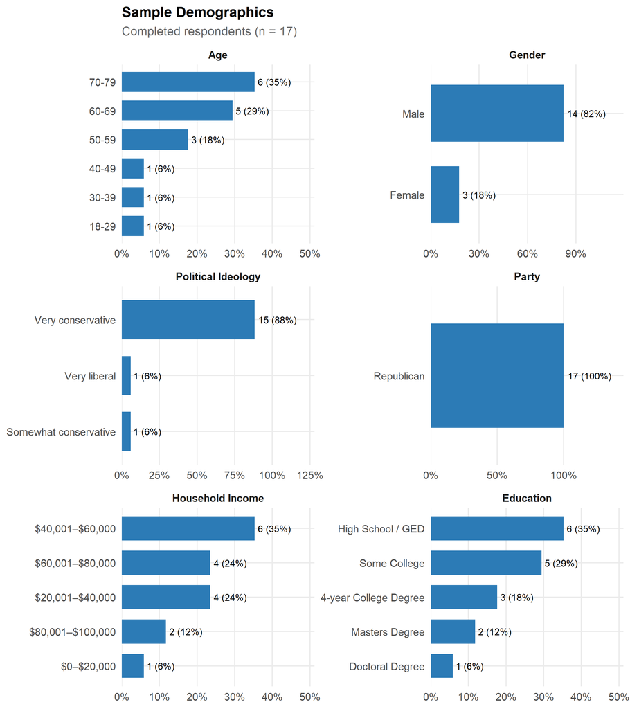

Table 1: Summary of sample demographics

| Characteristic | Top Category (n, %) |
| --- | --- |
| **N completed** | 17 |
| **Age** (most common) | 70-79 — 6 (35%) |
| **Gender** | Male — 14 (82%) |
| **Race / Ethnicity** | White — 13 (76%) |
| **Political Ideology** | Very conservative — 15 (88%) |
| **Party Affiliation** | Republican — 17 (100%) |
| **Household Income** | $40,001–$60,000 — 6 (35%) |
| **Education** | High School / GED — 6 (35%) |

**Key characteristics:** Tucker Carlson’s audience in this sample is heavily skewed toward older adults (65% are 60–79), male (82%), White (76%), and politically homogeneous — 88% “Very Conservative” and 100% Republican. Income is mostly middle-range ($20k–$80k), and educational attainment spans the full range, with the plurality holding a high school diploma or some college.

# 3 Tucker Carlson Engagement

## 3.1 Viewing Frequency and Familiarity

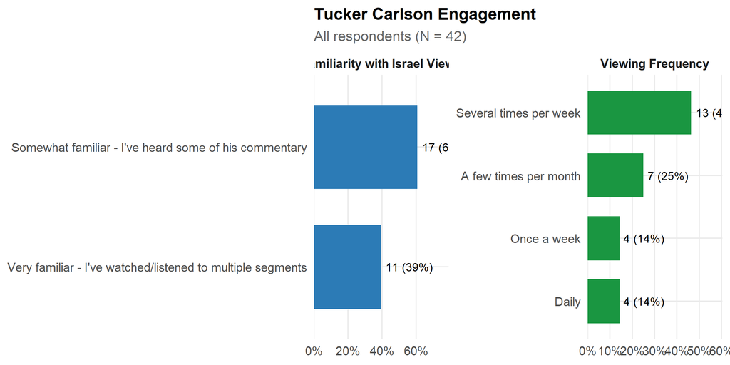

Figure 2: Viewing frequency and familiarity with Carlson’s Israel commentary

Respondents are regular, engaged viewers: **60% watch several times per week or daily**. All participants report at least some familiarity with Carlson’s commentary on Israel, and 39% describe themselves as “very familiar.”

## 3.2 Commentator Credibility Ratings

Participants used a 0–100 slider to rate how much each commentator “should be listened to.”

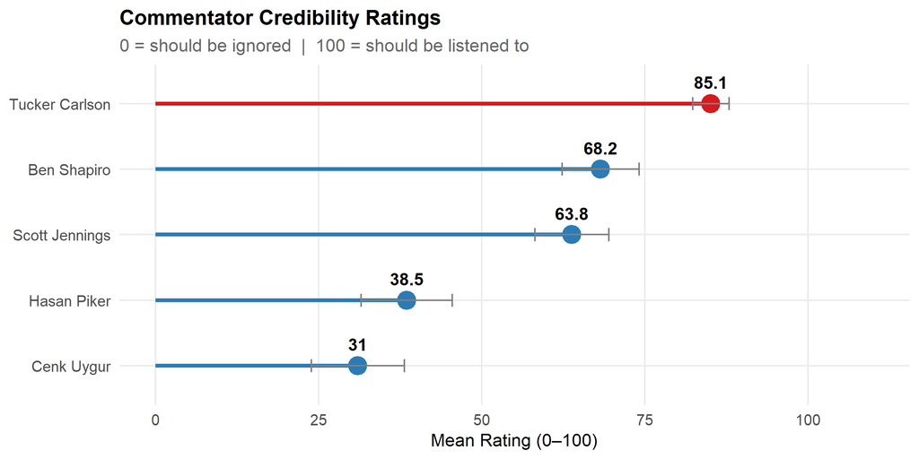

Figure 3: Mean ‘should be listened to’ ratings (0 = ignored, 100 = listened to)

Tucker Carlson’s mean rating of **85/100** far exceeds all other commentators. Conservative commentators (Shapiro: 68, Jennings: 64) are rated notably higher than progressive ones (Piker: 39, Uygur: 31), consistent with the ideological profile of the sample.

## 3.3 Why They Watch Tucker Carlson

Table 2: Open-ended responses: Why do you watch or listen to Tucker Carlson? (selected)

| Participant Response |
| --- |
| He’s a great dude and I really love to hear what he has to say |
| I like him |
| i trust the news that he delivers |
| For conservative perspectives, political analysis, and views aligning with mine. |
| I like his pollitical take on things |
| I try to seek balance when I listen to political pendant. I listened to people on the left and now on the right. So that’s why I do listen to him. |
| I believe he is interesting and is factually motivated |
| He has changed a lot of his views on world problems. I believe everyone should have a voice as long as they do not run down their country of origin. |
| Because what he says resonates with me and I enjoy listening to him |
| I agree with the same views. |
| I watch Tucker Carlson to hear his perspective on current events and politics, especially conservative viewpoints. |
| I like his view point. |

Dominant themes: **ideological alignment** (“he shares my values,” “conservative perspective”), **trust** (“I trust the news he delivers”), and **entertainment/uniqueness** (“no BS,” “covers what others won’t”). Viewers are primarily motivated by political identity reinforcement rather than specific content topics.

# 4 Baseline Beliefs and Attitudes

## 4.1 Conspiracy and Fringe Beliefs

Participants rated five statements on a 1–5 Likert scale (1 = Strongly Disagree, 5 = Strongly Agree).

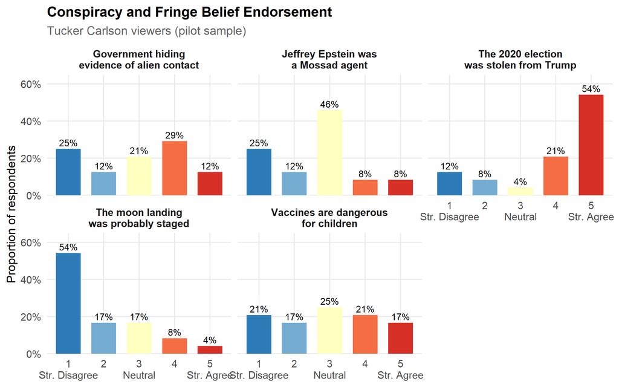

Figure 4: Distribution of conspiracy/fringe belief endorsement (1–5 scale)

## 4.2 Foreign Policy Views (Pre-Treatment)

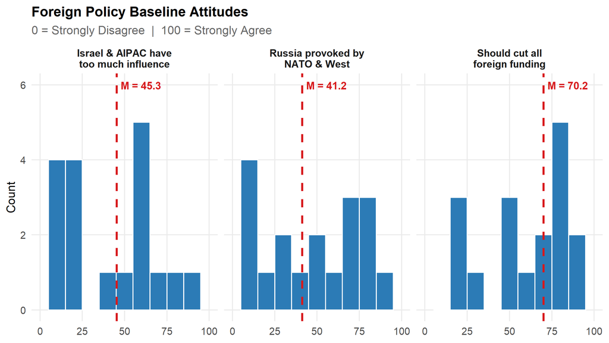

Figure 5: Baseline foreign policy attitude distributions (0–100 slider)

## 4.3 Feelings Toward Israel and Jewish People (Pre-Treatment)

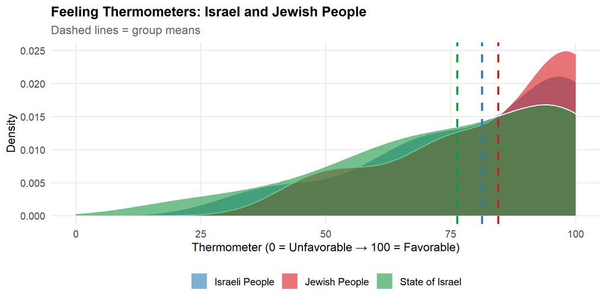

Figure 6: Baseline feeling thermometer ratings (0 = Extremely Unfavorable, 100 = Extremely Favorable)

Feeling thermometer summary statistics (pre-treatment)

| item | M | SD | Md | N |
| --- | --- | --- | --- | --- |
| Israeli People | 81.3 | 20.5 | 88 | 23 |
| Jewish People | 84.5 | 18.5 | 94 | 23 |
| State of Israel | 76.3 | 23.3 | 78 | 23 |

Baseline thermometer ratings are **consistently warm** — all three means exceed 75/100 — suggesting that Tucker Carlson’s audience, despite his skepticism toward U.S.-Israel policy, does not hold cold or hostile feelings toward Israeli or Jewish people at the individual level.

# 5 Experimental Conditions

Table 3: Distribution of experimental conditions (Block Randomizer)

| Condition | n | % |
| --- | --- | --- |
| Block 3a: Basic Persuasion | 12 | 52% |
| Block 3b: Ben Shapiro Persuasion | 11 | 48% |

Participants were randomly assigned to experimental conditions via a block randomizer. The condition variable should be used to stratify pre/post analyses in the full-scale study; given the small pilot sample, all conditions are analyzed together here to maximize statistical power.

# 6 Pre- to Post-Treatment Attitude Changes

The AI-delivered conversation provided factual context about Israel, U.S.-Israel relations, and related topics. Participants completed the same attitude batteries before and after the conversation. All scales are 0–100.

## 6.1 Credibility of Tucker Carlson

Table 4: Tucker Carlson credibility: pre vs. post (0 = Strongly Disagree, 100 = Strongly Agree)

Tucker Carlson Credibility (0–100 sliders)

| Item | n | Pre M | Post M | Δ | d | p |
| --- | --- | --- | --- | --- | --- | --- |
| Trusts his foreign policy analysis | 17 | 80.3 | 69.6 | -10.6 | -0.53 | 0.045 * |
| He almost always gets the facts right | 17 | 78.8 | 66.5 | -12.3 | -0.55 | 0.038 * |
| His predictions are usually accurate | 17 | 79.2 | 68.4 | -10.8 | -0.50 | 0.056 † |
| Covers important topics others ignore | 17 | 77.1 | 76.2 | -0.9 | -0.02 | 0.922 |
| Effectively challenges mainstream narratives | 17 | 84.1 | 82.0 | -2.1 | -0.10 | 0.686 |
| He often gets things wrong | 17 | 29.8 | 32.9 | +3.1 | 0.11 | 0.658 |

All scales: 0–100. d = Cohen's d for paired differences. † p<.10, * p<.05, ** p<.01, *** p<.001.

## 6.2 Foreign Policy Views

Table 5: Foreign policy views: pre vs. post (0 = Strongly Disagree, 100 = Strongly Agree)

Foreign Policy Views (0–100 sliders)

| Item | n | Pre M | Post M | Δ | d | p |
| --- | --- | --- | --- | --- | --- | --- |
| Russia was provoked by NATO and the West | 17 | 39.8 | 31.6 | -8.1 | -0.44 | 0.086 † |
| Israel and AIPAC have too much influence over America | 17 | 38.8 | 36.2 | -2.6 | -0.09 | 0.703 |
| We should cut all funding to foreign countries | 17 | 67.6 | 43.1 | -24.5 | -0.95 | 0.001 ** |

All scales: 0–100. d = Cohen's d for paired differences. † p<.10, * p<.05, ** p<.01, *** p<.001.

## 6.3 Feelings Toward Israel and Jewish People

Table 6: Feeling thermometers: pre vs. post (0 = Extremely Unfavorable, 100 = Extremely Favorable)

Feeling Thermometers (0–100)

| Item | n | Pre M | Post M | Δ | d | p |
| --- | --- | --- | --- | --- | --- | --- |
| Israeli people | 17 | 79.2 | 79.1 | -0.1 | -0.01 | 0.972 |
| Jewish people | 17 | 81.9 | 78.0 | -3.9 | -0.22 | 0.375 |
| The State of Israel | 17 | 77.6 | 76.1 | -1.6 | -0.08 | 0.734 |

All scales: 0–100. d = Cohen's d for paired differences. † p<.10, * p<.05, ** p<.01, *** p<.001.

## 6.4 Tucker Carlson’s Israel Commentary

Table 7: Perceptions of Tucker Carlson’s Israel commentary: pre vs. post (0–100)

Tucker Carlson's Israel Commentary (0–100 sliders)

| Item | n | Pre M | Post M | Δ | d | p |
| --- | --- | --- | --- | --- | --- | --- |
| His commentary on Israel is accurate and fair | 17 | 73.5 | 62.1 | -11.4 | -0.49 | 0.063 † |
| He asks the right questions about America's relationship with Israel | 17 | 75.1 | 69.3 | -5.8 | -0.29 | 0.254 |
| He is too critical of Israel | 17 | 54.3 | 55.0 | +0.7 | 0.03 | 0.897 |
| He understands the Middle East better than most commentators | 17 | 76.3 | 63.8 | -12.5 | -0.41 | 0.113 |

All scales: 0–100. d = Cohen's d for paired differences. † p<.10, * p<.05, ** p<.01, *** p<.001.

## 6.5 Israel Policy Positions

Table 8: Israel policy views: pre vs. post (0 = Strongly Disagree, 100 = Strongly Agree)

Israel Policy Views (0–100 sliders)

| Item | n | Pre M | Post M | Δ | d | p |
| --- | --- | --- | --- | --- | --- | --- |
| The U.S.–Israel relationship benefits the United States | 17 | 73.1 | 75.0 | +1.9 | 0.10 | 0.692 |
| Israel has a legitimate right to exist as a Jewish state | 17 | 84.1 | 84.5 | +0.4 | 0.04 | 0.858 |
| Israel generally acts morally in its self-defense | 17 | 78.4 | 76.1 | -2.3 | -0.14 | 0.581 |
| The U.S. should reduce military aid to Israel | 17 | 43.7 | 50.4 | +6.7 | 0.23 | 0.360 |

All scales: 0–100. d = Cohen's d for paired differences. † p<.10, * p<.05, ** p<.01, *** p<.001.

**Core Israel policy positions were entirely unmoved.** Israel’s right to exist (M ≈ 85), moral conduct (M ≈ 76), and the US-Israel relationship (M ≈ 75) show near-zero pre/post differences. These are deeply entrenched beliefs even among Tucker Carlson viewers, suggesting the factual intervention does not threaten foundational Israel support — its effects are more narrowly targeted at policy mechanisms (foreign aid) and Carlson’s specific credibility.

## 6.6 Summary: All Pre/Post Changes

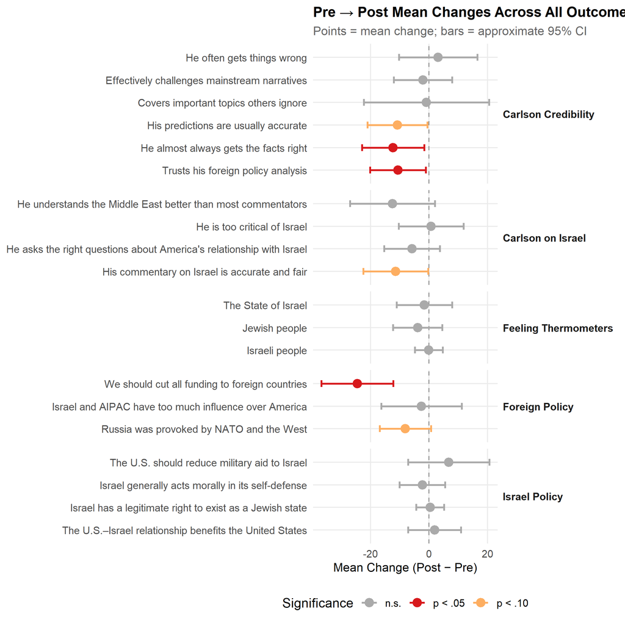

Figure 7: All pre/post mean changes with approximate 95% confidence intervals. Red = statistically significant (p < .05), orange = marginal (p < .10), grey = non-significant.

# 7 Audience Segmentation

To identify meaningful sub-groups within Tucker Carlson’s audience, we applied **k-means clustering** to participants’ pre-treatment attitude scores across all five domains (conspiracy beliefs, foreign policy views, feeling thermometers, Tucker on Israel, Israel policy positions). Missing values were median-imputed. Optimal k was selected by silhouette analysis.

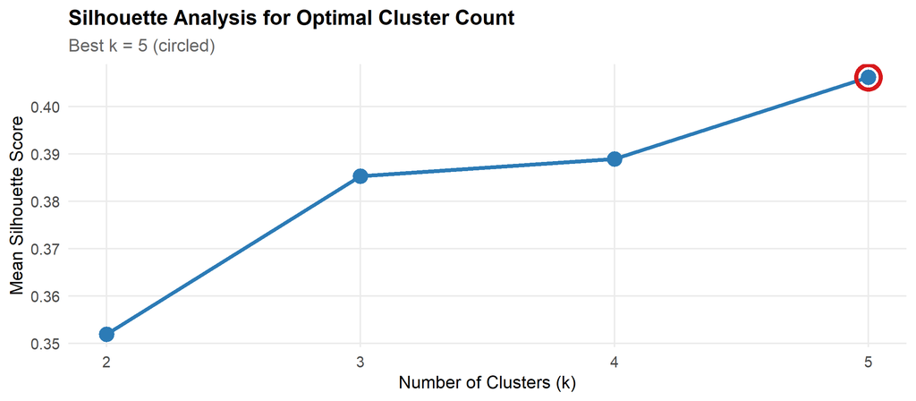

Figure 8: Silhouette scores by number of clusters (higher = better fit)

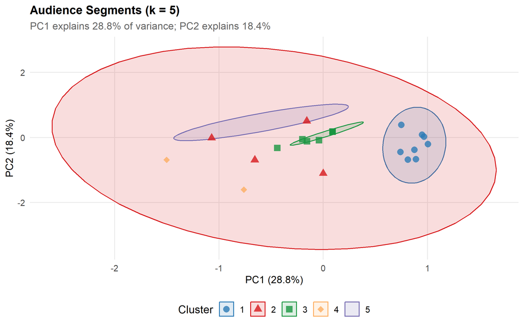

Figure 9: Audience segments visualized via PCA (first two principal components)

Table 9: Cluster mean profiles on key attitude dimensions

[output not shown]

# 8 Qualitative Themes

## 8.1 Has Tucker Changed Their Views on Israel?

Table 10: Has Tucker Carlson’s commentary influenced your views on Israel? (Q13)

| Response | n | % |
| --- | --- | --- |
| No impact on my views | 9 | 39% |
| Reinforced views I already held | 6 | 26% |
| Yes, significantly changed my views | 1 | 4% |
| Yes, somewhat influenced my views | 7 | 30% |

## 8.2 What Tucker Gets Right About Israel

Table 11: Open-ended: What do you think Tucker Carlson gets right about Israel? (selected responses)

| Participant Response |
| --- |
| everything seems to be right |
| How Israel and USA relationship ship benefits the USA. |
| That we should stop sending foreign aid and money to help |
| He highlights strategic issues and questions U.S. policy toward Israel. |
| That's important questions that other commentators do not ask or talk about. |
| almost everything and since israel is talked about in the bible |
| I think they DO have to much influence in our own affairs, I do believe they have every right to exist as a nation, but the genocide in Gaza, is just too much. Go after the ones that attacked you, not… |
| The right to defend itself and it's liberty from countries that want to take this freedom away such as Iran and Hamas. |
| Tucker is right about Israel when he says that we're too much under their thumb. The relationship between the US and Israel is mostly one sided. We do a lot more for Israel than they do for us. Israel… |
| He believes they have aright to exist and he believes they have a right to defend themselves |
| How the US should deal with them |

**Emergent themes:**

1. **Foreign aid skepticism** — “We send too much money,” “we should stop sending foreign aid.” This is the most common frame, consistent with the strong pre-treatment support for cutting foreign funding.
2. **Asking questions others won’t** — “He asks questions that no other commentator asks,” “makes you think.” Viewers value Carlson as a contrarian voice, independent of whether his specific claims are accurate.
3. **Israel’s right to exist and defend itself** — Notably, a subset affirm Tucker’s support for Israeli sovereignty, indicating this group does not share blanket anti-Israel views.
4. **US-Israel power dynamics** — “We’re too much under their thumb,” “AIPAC has too much influence.” This framing is more prominent than outright hostility to Israel.

## 8.3 Post-Conversation Reflections

Table 12: Open-ended: Did the conversation change how you think about Tucker Carlson or Israel? (selected)

| Question | Participant Response |
| --- | --- |
| Changed views on Tucker? | A couple of things made me think a little differently, but no, not really |
| Changed views on Tucker? | No, it reinforced my views on his skepticism and analysis of key issues. |
| Changed views on Tucker? | My views on Tucker Carlson has not changed |
| Changed views on Tucker? | Yes I would like to hear other viewpoints |
| Changed views on Tucker? | Nothing |
| Changed views on Tucker? | Yes it does change my opinion of him a little bit which is why I have not watched him as much |
| Changed views on Israel? | No, not at this time |
| Changed views on Israel? | No, my views on Israel and U.S. policy toward it remain unchanged. |
| Changed views on Israel? | No. I have always considered them a legitimate 100% State. I think there was a time in a place where they needed to rely much much more on the United States than they do right now. Again, could thi... |
| Changed views on Israel? | Nothing has changed |
| Changed views on Israel? | No not at all |
| Changed views on Israel? | I still have great support for Israel more than ever |

Most respondents said the conversation **did not change their views**, reflecting the motivated reasoning and strong prior commitments typical of partisan media audiences. A minority described the conversation as “thought-provoking” or noted it “raised questions” about Carlson’s accuracy — consistent with the marginal but real shifts observed in the quantitative measures.

# 9 Key Findings

Table 13: Summary of principal quantitative findings

[output not shown]

**Interpretation:** The AI-delivered factual conversation was most effective at shifting **policy-adjacent beliefs** (foreign aid levels) and **media-source credibility evaluations** (Tucker’s Israel accuracy), while leaving **foundational identity-tied beliefs** (Israel’s legitimacy, Jewish people thermometer) entirely intact. This pattern is consistent with dual-process models of persuasion: peripheral or instrumental beliefs shift under informational pressure, while core identity-linked beliefs are resistant. The foreign aid finding is particularly striking and warrants replication at full scale.

# Appendix: Technical Notes

**Data source:** PrimePanels online panel; recruited as self-identified Tucker Carlson viewers.

**Survey platform:** AI-driven conversational interview (system-administered). Pre-treatment questions: 1–12; AI conversation: embedded between Q16 and Q18; post-treatment questions: 18–22; demographics: Q26–Q35.

**Statistical tests:** Paired two-sided t-tests on row-matched pre/post observations. Effect size reported as Cohen’s *d* for paired differences (d = mean difference / SD of differences).

**Clustering:** K-means clustering (25 random starts, 100 max iterations) on scaled pre-treatment attitude items. Missing values median-imputed. Optimal k selected by mean silhouette score.

**Significance conventions:** *** p < .001, ** p < .01, * p < .05, † p < .10. All p-values are two-sided. Given the pilot sample size (n ≈ 17 completed), all results should be treated as exploratory and replicated at adequate power (estimated n ≥ 200 for detecting d = 0.3 at 80% power).